# Take-home Exercise 1: Motor Vehicle Insurance Portfolio Analysis

Executive Summary

Trinh Minh Tam

2026-05-20

## Introduction

> “Leveraging visual analytics can potentially help investigate trends in underlying loss drivers, while data enrichment can help refine segmentation and underwriting strategy.” — *Swiss Re, sigma 4/2019*

**Objectives:**

- Explore distributions of **numerical** and **categorical** portfolio variables
- Statistically validate key factors driving **profitability** (loss ratio) and **volatility** (claim frequency)

Full technical report →

## Dataset at a Glance

**Portfolio data**

| **Source** | Mendeley Data — Spanish non-life insurer |
| --- | --- |
| **Records** | 354,140 policy-year observations |
| **Period** | 2022 – 2024 |
| **Variables** | 47 raw + 5 derived KPIs |
| **After filtering** | 352,165 (0.6% removed: LR > 50) |

**Three core actuarial KPIs**

| KPI | Formula | Measures |
| --- | --- | --- |
| **Loss Ratio** | Incurred / Premium | Profitability |
| **Claim Freq.** | Claims / Exposure | Volatility |
| **Avg. Severity** | Incurred / Claims | Cost per claim |

**Key context:** Loss ratio and claim frequency are **zero-inflated** — most policies have no claims, so all group medians equal 0.00. Risk differences appear in the **upper tail**, not the median.

Data wrangling →

## Portfolio Composition

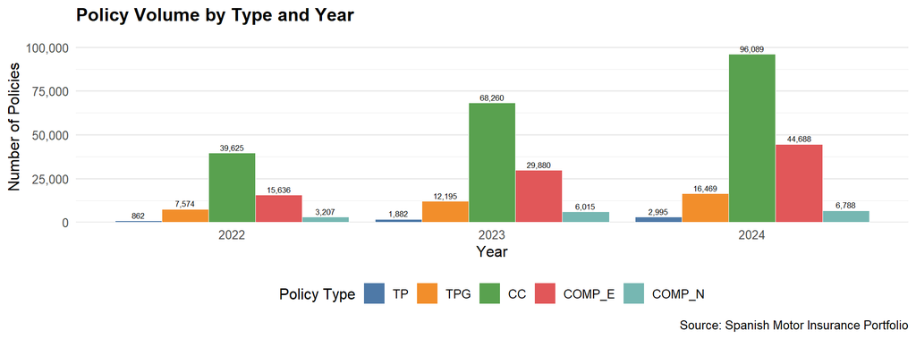

**What the chart shows:**

CC dominance means profitability and volatility are primarily driven by this product line, even though COMP_N/COMP_E carry higher individual risk.

Full analysis →

## Portfolio Risk Profile

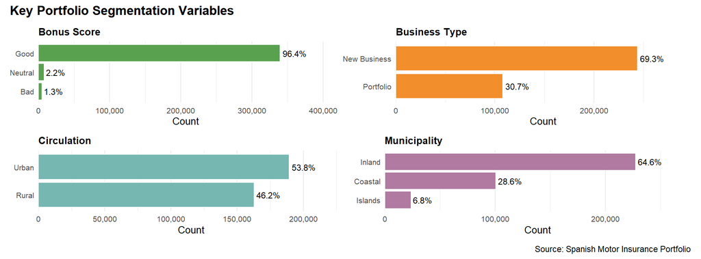

**Key segmentation facts:**

**Bonus Score:** 96.4% of policyholders are in the **Good** category — a very low-risk base with limited adverse selection exposure

**Business Type:** **New Business dominates at 69.3%** vs Portfolio 30.7% — likely reflects first-year policy classification in this dataset

**Circulation:** Urban (53.8%) > Rural (46.2%) — urban concentration brings higher collision and theft exposure

**Municipality:** Inland (64.6%) accounts for the majority, consistent with Spain’s population distribution

The 96.4% Good-score concentration is the portfolio’s key structural advantage — it naturally suppresses overall claim frequency.

Full distributions →

## Loss Ratio: Why Medians Are Misleading Here

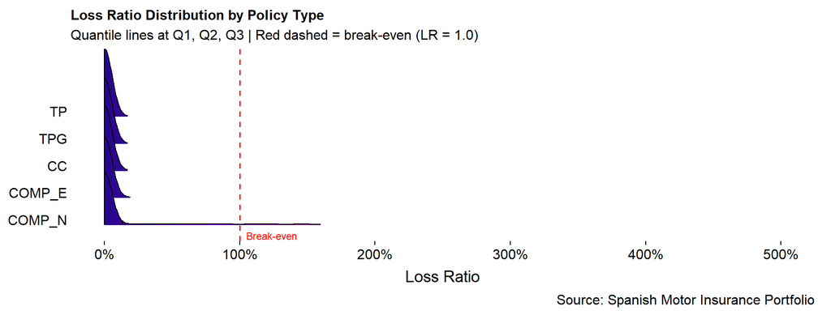

**Reading this chart:**

All subsequent statistical tests detect **tail differences**, not median differences. This is by design, not a limitation.

Full ridgeline analysis →

## Profitability Driver 1: Bonus Score

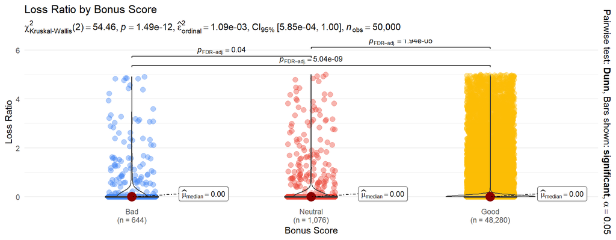

**Statistical findings:**

- **All 3 pairwise comparisons** are significant after BH correction — including **Good vs Neutral** (p ≈ 0.00002), showing fine-grained discrimination at every level
- All **medians = 0.00** (zero-inflated); the test detects **rank distribution differences** in the upper tail
- **Bad-score** policyholders generate a visibly heavier scatter of high-LR observations — they disproportionately drive the portfolio’s large, unprofitable claims
- **Effect size** is small but consistent, confirming this is a real signal, not noise

Full analysis →

## Profitability Driver 2: Policy Type

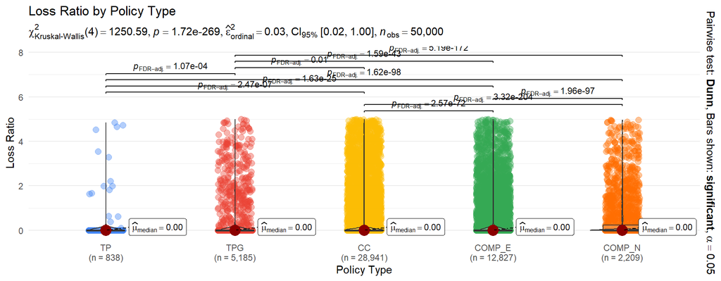

**What the tests confirm:**

- All **medians = 0.00** across all five types — but rank distributions differ significantly (p ≈ 0 across pairwise tests)
- **COMP_N** has the **heaviest upper tail** — no deductible removes the financial barrier to small claims, compounding over time
- **COMP_E vs COMP_N**: the deductible in COMP_E acts as a meaningful brake — COMP_E shows a significantly lower risk distribution
- **TP and TPG** are the most profitable lines — their narrow liability-only scope rarely generates large incurred costs

**COMP_N warrants a pricing adequacy review** — its no-excess structure drives disproportionate tail risk relative to COMP_E.

Full analysis →

## Profitability Driver 3: Driver Age

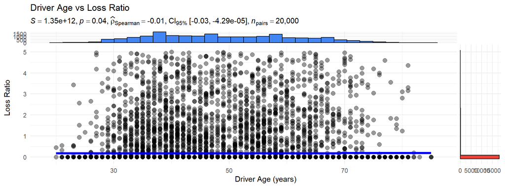

**What the chart reveals:**

Age is a **secondary pricing factor** — real and significant, but smaller in magnitude than bonus score or policy type.

Full analysis →

## Volatility: Claim Frequency by Policy Type

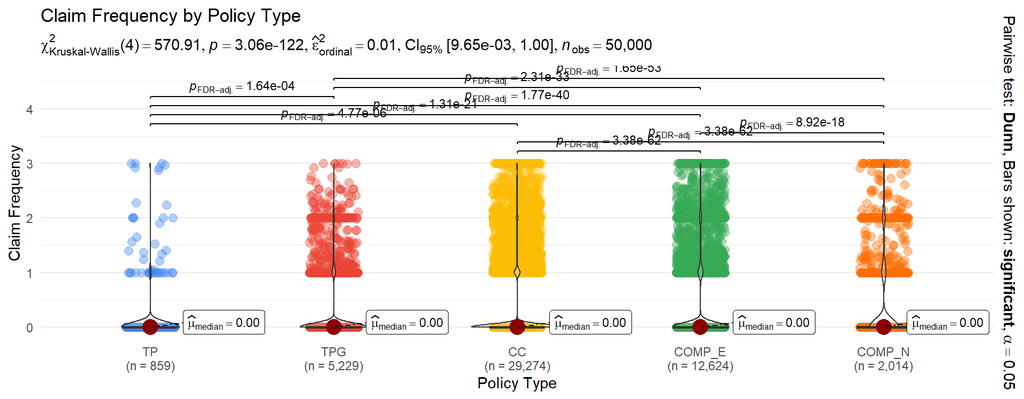

**What the tests show:**

- All **medians = 0.00** — but rank distributions confirm a clear ordering: **COMP_N > COMP_E > CC > TP** (all pairwise differences significant, p ≈ 0)
- **COMP_N > COMP_E**: absence of excess removes the financial incentive to avoid minor claims — even small glass or scratch events get reported
- The compounding effect is critical: comprehensive products generate **both** higher frequency **and** higher severity, explaining their elevated loss ratios
- For **bonus score** and frequency, only the **Bad–Good** comparison is significant — a weaker effect than on loss ratio

Frequency and severity compound for COMP_N — **both** dimensions must be addressed in any pricing review.

Full volatility analysis →

## Claim Incidence: Bonus Score & Fuel Type

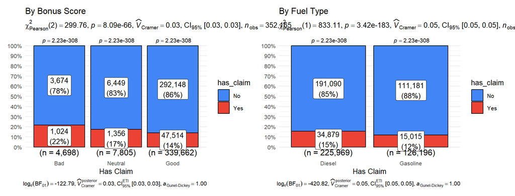

**Bonus score vs claim incidence:**

- **Bad: 22%** vs **Good: 14%** claim rate — a **1.6× difference**, highly significant (χ² = 299.76, p ≈ 0)
- Unlike `ggbetweenstats`, `ggbarstats` measures **binary incidence** (did any claim occur?), so zero-inflation is not a concern here
- Good segment’s 96.4% dominance keeps the **overall portfolio incidence rate low**

**Fuel type vs claim incidence:**

- **Diesel: 15%** vs **Gasoline: 12%** — statistically significant (χ² = 833.11, p ≈ 0) but largely a **coverage mix effect**
- Diesel vehicles carry more COMP_E/COMP_N policies, which have more claimable event types (glass, theft, own damage)

Full association analysis →

## Vehicle Brand Risk Landscape

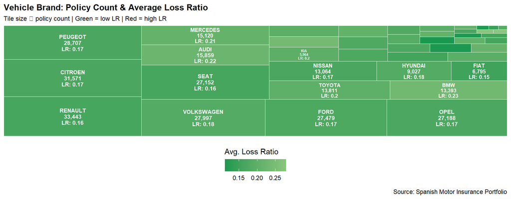

**How to read this chart:**

- **Tile size** = number of policies (concentration risk)
- **Tile colour** = average loss ratio (green = profitable, red = loss-making)
- **Best case:** Large tile + green = high volume and profitable
- **Concern:** Small tile + red = low volume but elevated loss ratio

**Key observations:**

This view enables **brand-level underwriting decisions** — something a standard bar chart cannot show.

Full treemap analysis →

## Year-over-Year Profitability Trend

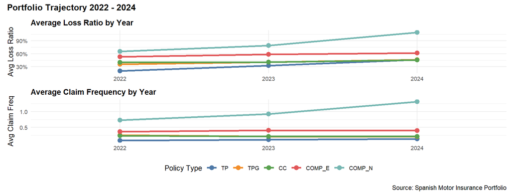

**What the trend reveals:**

The 3-year trajectory **reinforces and dates** the cross-sectional finding: COMP_N risk is not just structural - it is **getting worse**.

Technical detail →

## Key Findings & Implications

**Profitability (Loss Ratio)**

**Claim Incidence**

- Bad bonus: **22%** vs Good: **14%** — 1.6× difference
- Diesel: **15%** vs Gasoline: **12%** — coverage mix effect

**Volatility (Claim Frequency)**

- **COMP_N > COMP_E > CC > TP** — frequency tail mirrors loss ratio ordering
- Compounding effect: comprehensive drives **both** higher frequency **and** higher severity
- **Bad–Good** bonus comparison is significant (weaker than LR effect)
- Good bonus (96.4% of portfolio) → natural frequency protection

**Strategic implication:**

Pricing models should prioritise **bonus score** and **policy type** as primary factors, with **driver age** and **circulation area** providing incremental lift. **COMP_N** specifically warrants a pricing adequacy review given its compounding frequency + severity risk profile.

Full summary →

## Conclusion & Recommendations

**Three actionable recommendations** for the underwriting and pricing team, in priority order:

**1. Price COMP_N for the tail risk it carries**

COMP_N shows the heaviest upper-tail loss ratio **and** the highest claim frequency **and** the steepest year-on-year deterioration. Conduct a pricing adequacy review with a target loading of **+15% to +25%** versus COMP_E, plus consider mandatory excess on small claims.

**2. Tier bonus score with finer granularity**

The Good–Neutral comparison is statistically significant (p ≈ 0.00002) - the current 3-tier structure under-discriminates. Move to a **5- or 7-tier system** with explicit rate differentials at each step.

**3. Apply a young-driver loading across all products**

**Expected portfolio impact**

✓ **Tail risk reduction** in the COMP_N segment, which drives a disproportionate share of large incurred losses

✓ **Sharper risk selection** through bonus tiering — particularly useful for retention pricing on Neutral-tier renewals

**What this analysis does *not* answer**

- Multivariate interactions (e.g. young driver **and** COMP_N) - requires a GLM
- Customer lifetime value and elasticity to price changes
- External factors: inflation, vehicle parts supply, regulatory changes

**Next step:** build a GLM with these three factors as primary terms and validate on a 2024 hold-out sample.

Full summary →